# Optimal Treatment Analysis

## Outcome Variable

**Outcome Variable:** ever_stunted

## Predictor Variables

**Intervention Variable:** perdiar24

**Adjustment Set:**

- arm
- sex
- W_birthwt
- W_birthlen
- W_nrooms
- month
- brthmon
- impfloor
- impsan
- safeh20
- delta_W_birthwt
- delta_W_birthlen
- delta_W_nrooms
- delta_month
- delta_brthmon
- delta_impfloor
- delta_impsan
- delta_safeh20

## Stratifying Variables

The analysis was stratified on these variable(s):

- agecat
- studyid
- country

## Data Summary

| agecat | studyid | country | perdiar24 | ever_stunted | n_cell | n |
| --- | --- | --- | --- | --- | --- | --- |
| 0-24 months (no birth st.) | ki0047075b-MAL-ED | BANGLADESH | (0%, 5%] | 0 | 63 | 217 |
| 0-24 months (no birth st.) | ki0047075b-MAL-ED | BANGLADESH | (0%, 5%] | 1 | 65 | 217 |
| 0-24 months (no birth st.) | ki0047075b-MAL-ED | BANGLADESH | >5% | 0 | 31 | 217 |
| 0-24 months (no birth st.) | ki0047075b-MAL-ED | BANGLADESH | >5% | 1 | 42 | 217 |
| 0-24 months (no birth st.) | ki0047075b-MAL-ED | BANGLADESH | 0% | 0 | 10 | 217 |
| 0-24 months (no birth st.) | ki0047075b-MAL-ED | BANGLADESH | 0% | 1 | 6 | 217 |
| 0-24 months (no birth st.) | ki0047075b-MAL-ED | BRAZIL | (0%, 5%] | 0 | 71 | 208 |
| 0-24 months (no birth st.) | ki0047075b-MAL-ED | BRAZIL | (0%, 5%] | 1 | 17 | 208 |
| 0-24 months (no birth st.) | ki0047075b-MAL-ED | BRAZIL | >5% | 0 | 2 | 208 |
| 0-24 months (no birth st.) | ki0047075b-MAL-ED | BRAZIL | >5% | 1 | 0 | 208 |
| 0-24 months (no birth st.) | ki0047075b-MAL-ED | BRAZIL | 0% | 0 | 106 | 208 |
| 0-24 months (no birth st.) | ki0047075b-MAL-ED | BRAZIL | 0% | 1 | 12 | 208 |
| 0-24 months (no birth st.) | ki0047075b-MAL-ED | INDIA | (0%, 5%] | 0 | 73 | 209 |
| 0-24 months (no birth st.) | ki0047075b-MAL-ED | INDIA | (0%, 5%] | 1 | 87 | 209 |
| 0-24 months (no birth st.) | ki0047075b-MAL-ED | INDIA | >5% | 0 | 19 | 209 |
| 0-24 months (no birth st.) | ki0047075b-MAL-ED | INDIA | >5% | 1 | 18 | 209 |
| 0-24 months (no birth st.) | ki0047075b-MAL-ED | INDIA | 0% | 0 | 9 | 209 |
| 0-24 months (no birth st.) | ki0047075b-MAL-ED | INDIA | 0% | 1 | 3 | 209 |
| 0-24 months (no birth st.) | ki0047075b-MAL-ED | NEPAL | (0%, 5%] | 0 | 95 | 212 |
| 0-24 months (no birth st.) | ki0047075b-MAL-ED | NEPAL | (0%, 5%] | 1 | 36 | 212 |
| 0-24 months (no birth st.) | ki0047075b-MAL-ED | NEPAL | >5% | 0 | 50 | 212 |
| 0-24 months (no birth st.) | ki0047075b-MAL-ED | NEPAL | >5% | 1 | 17 | 212 |
| 0-24 months (no birth st.) | ki0047075b-MAL-ED | NEPAL | 0% | 0 | 12 | 212 |
| 0-24 months (no birth st.) | ki0047075b-MAL-ED | NEPAL | 0% | 1 | 2 | 212 |
| 0-24 months (no birth st.) | ki0047075b-MAL-ED | PERU | (0%, 5%] | 0 | 34 | 266 |
| 0-24 months (no birth st.) | ki0047075b-MAL-ED | PERU | (0%, 5%] | 1 | 65 | 266 |
| 0-24 months (no birth st.) | ki0047075b-MAL-ED | PERU | >5% | 0 | 60 | 266 |
| 0-24 months (no birth st.) | ki0047075b-MAL-ED | PERU | >5% | 1 | 80 | 266 |
| 0-24 months (no birth st.) | ki0047075b-MAL-ED | PERU | 0% | 0 | 21 | 266 |
| 0-24 months (no birth st.) | ki0047075b-MAL-ED | PERU | 0% | 1 | 6 | 266 |

[output cut: 342 more lines]

The following strata were considered:

- agecat: 0-24 months (no birth st.), studyid: ki0047075b-MAL-ED, country: BANGLADESH
- agecat: 0-24 months (no birth st.), studyid: ki0047075b-MAL-ED, country: BRAZIL
- agecat: 0-24 months (no birth st.), studyid: ki0047075b-MAL-ED, country: INDIA
- agecat: 0-24 months (no birth st.), studyid: ki0047075b-MAL-ED, country: NEPAL
- agecat: 0-24 months (no birth st.), studyid: ki0047075b-MAL-ED, country: PERU
- agecat: 0-24 months (no birth st.), studyid: ki0047075b-MAL-ED, country: SOUTH AFRICA
- agecat: 0-24 months (no birth st.), studyid: ki0047075b-MAL-ED, country: TANZANIA, UNITED REPUBLIC OF
- agecat: 0-24 months (no birth st.), studyid: ki1000109-EE, country: PAKISTAN
- agecat: 0-24 months (no birth st.), studyid: ki1000109-ResPak, country: PAKISTAN
- agecat: 0-24 months (no birth st.), studyid: ki1000304b-SAS-FoodSuppl, country: INDIA
- agecat: 0-24 months (no birth st.), studyid: ki1017093-NIH-Birth, country: BANGLADESH
- agecat: 0-24 months (no birth st.), studyid: ki1017093b-PROVIDE, country: BANGLADESH
- agecat: 0-24 months (no birth st.), studyid: ki1017093c-NIH-Crypto, country: BANGLADESH
- agecat: 0-24 months (no birth st.), studyid: ki1112895-Guatemala BSC, country: GUATEMALA
- agecat: 0-24 months (no birth st.), studyid: ki1112895-iLiNS-Zinc, country: BURKINA FASO
- agecat: 0-24 months (no birth st.), studyid: ki1114097-CMIN, country: BANGLADESH
- agecat: 0-24 months (no birth st.), studyid: ki1114097-CMIN, country: BRAZIL
- agecat: 0-24 months (no birth st.), studyid: ki1114097-CMIN, country: GUINEA-BISSAU
- agecat: 0-24 months (no birth st.), studyid: ki1114097-CMIN, country: PERU
- agecat: 0-24 months (no birth st.), studyid: ki1114097-CONTENT, country: PERU
- agecat: 0-24 months (no birth st.), studyid: kiGH5241-JiVitA-4, country: BANGLADESH
- agecat: 0-6 months (no birth st.), studyid: ki0047075b-MAL-ED, country: BANGLADESH
- agecat: 0-6 months (no birth st.), studyid: ki0047075b-MAL-ED, country: BRAZIL
- agecat: 0-6 months (no birth st.), studyid: ki0047075b-MAL-ED, country: INDIA
- agecat: 0-6 months (no birth st.), studyid: ki0047075b-MAL-ED, country: NEPAL
- agecat: 0-6 months (no birth st.), studyid: ki0047075b-MAL-ED, country: PERU
- agecat: 0-6 months (no birth st.), studyid: ki0047075b-MAL-ED, country: SOUTH AFRICA
- agecat: 0-6 months (no birth st.), studyid: ki0047075b-MAL-ED, country: TANZANIA, UNITED REPUBLIC OF
- agecat: 0-6 months (no birth st.), studyid: ki1000109-EE, country: PAKISTAN
- agecat: 0-6 months (no birth st.), studyid: ki1000109-ResPak, country: PAKISTAN
- agecat: 0-6 months (no birth st.), studyid: ki1000304b-SAS-FoodSuppl, country: INDIA
- agecat: 0-6 months (no birth st.), studyid: ki1017093-NIH-Birth, country: BANGLADESH
- agecat: 0-6 months (no birth st.), studyid: ki1017093b-PROVIDE, country: BANGLADESH
- agecat: 0-6 months (no birth st.), studyid: ki1017093c-NIH-Crypto, country: BANGLADESH
- agecat: 0-6 months (no birth st.), studyid: ki1112895-Guatemala BSC, country: GUATEMALA
- agecat: 0-6 months (no birth st.), studyid: ki1114097-CMIN, country: BANGLADESH
- agecat: 0-6 months (no birth st.), studyid: ki1114097-CMIN, country: BRAZIL
- agecat: 0-6 months (no birth st.), studyid: ki1114097-CMIN, country: GUINEA-BISSAU
- agecat: 0-6 months (no birth st.), studyid: ki1114097-CMIN, country: PERU
- agecat: 0-6 months (no birth st.), studyid: ki1114097-CONTENT, country: PERU
- agecat: 0-6 months (no birth st.), studyid: kiGH5241-JiVitA-4, country: BANGLADESH
- agecat: 6-24 months, studyid: ki0047075b-MAL-ED, country: BANGLADESH
- agecat: 6-24 months, studyid: ki0047075b-MAL-ED, country: BRAZIL
- agecat: 6-24 months, studyid: ki0047075b-MAL-ED, country: INDIA
- agecat: 6-24 months, studyid: ki0047075b-MAL-ED, country: NEPAL
- agecat: 6-24 months, studyid: ki0047075b-MAL-ED, country: PERU
- agecat: 6-24 months, studyid: ki0047075b-MAL-ED, country: SOUTH AFRICA
- agecat: 6-24 months, studyid: ki0047075b-MAL-ED, country: TANZANIA, UNITED REPUBLIC OF
- agecat: 6-24 months, studyid: ki1000109-EE, country: PAKISTAN
- agecat: 6-24 months, studyid: ki1000109-ResPak, country: PAKISTAN
- agecat: 6-24 months, studyid: ki1000304b-SAS-FoodSuppl, country: INDIA
- agecat: 6-24 months, studyid: ki1017093-NIH-Birth, country: BANGLADESH
- agecat: 6-24 months, studyid: ki1017093b-PROVIDE, country: BANGLADESH
- agecat: 6-24 months, studyid: ki1017093c-NIH-Crypto, country: BANGLADESH
- agecat: 6-24 months, studyid: ki1112895-Guatemala BSC, country: GUATEMALA
- agecat: 6-24 months, studyid: ki1112895-iLiNS-Zinc, country: BURKINA FASO
- agecat: 6-24 months, studyid: ki1114097-CMIN, country: BANGLADESH
- agecat: 6-24 months, studyid: ki1114097-CMIN, country: BRAZIL
- agecat: 6-24 months, studyid: ki1114097-CMIN, country: GUINEA-BISSAU
- agecat: 6-24 months, studyid: ki1114097-CMIN, country: PERU
- agecat: 6-24 months, studyid: ki1114097-CONTENT, country: PERU
- agecat: 6-24 months, studyid: kiGH5241-JiVitA-4, country: BANGLADESH

### Dropped Strata

Some strata were dropped due to rare outcomes:

- agecat: 0-24 months (no birth st.), studyid: ki0047075b-MAL-ED, country: BRAZIL
- agecat: 0-24 months (no birth st.), studyid: ki0047075b-MAL-ED, country: INDIA
- agecat: 0-24 months (no birth st.), studyid: ki0047075b-MAL-ED, country: NEPAL
- agecat: 0-24 months (no birth st.), studyid: ki0047075b-MAL-ED, country: SOUTH AFRICA
- agecat: 0-24 months (no birth st.), studyid: ki1000109-EE, country: PAKISTAN
- agecat: 0-24 months (no birth st.), studyid: ki1017093b-PROVIDE, country: BANGLADESH
- agecat: 0-24 months (no birth st.), studyid: ki1114097-CMIN, country: BANGLADESH
- agecat: 0-24 months (no birth st.), studyid: ki1114097-CMIN, country: BRAZIL
- agecat: 0-24 months (no birth st.), studyid: ki1114097-CONTENT, country: PERU
- agecat: 0-6 months (no birth st.), studyid: ki0047075b-MAL-ED, country: BANGLADESH
- agecat: 0-6 months (no birth st.), studyid: ki0047075b-MAL-ED, country: BRAZIL
- agecat: 0-6 months (no birth st.), studyid: ki0047075b-MAL-ED, country: INDIA
- agecat: 0-6 months (no birth st.), studyid: ki0047075b-MAL-ED, country: NEPAL
- agecat: 0-6 months (no birth st.), studyid: ki0047075b-MAL-ED, country: SOUTH AFRICA
- agecat: 0-6 months (no birth st.), studyid: ki0047075b-MAL-ED, country: TANZANIA, UNITED REPUBLIC OF
- agecat: 0-6 months (no birth st.), studyid: ki1000304b-SAS-FoodSuppl, country: INDIA
- agecat: 0-6 months (no birth st.), studyid: ki1017093-NIH-Birth, country: BANGLADESH
- agecat: 0-6 months (no birth st.), studyid: ki1017093b-PROVIDE, country: BANGLADESH
- agecat: 0-6 months (no birth st.), studyid: ki1112895-Guatemala BSC, country: GUATEMALA
- agecat: 0-6 months (no birth st.), studyid: ki1114097-CMIN, country: BANGLADESH
- agecat: 0-6 months (no birth st.), studyid: ki1114097-CMIN, country: BRAZIL
- agecat: 0-6 months (no birth st.), studyid: ki1114097-CMIN, country: GUINEA-BISSAU
- agecat: 0-6 months (no birth st.), studyid: ki1114097-CMIN, country: PERU
- agecat: 0-6 months (no birth st.), studyid: ki1114097-CONTENT, country: PERU
- agecat: 6-24 months, studyid: ki0047075b-MAL-ED, country: BANGLADESH
- agecat: 6-24 months, studyid: ki0047075b-MAL-ED, country: BRAZIL
- agecat: 6-24 months, studyid: ki0047075b-MAL-ED, country: INDIA
- agecat: 6-24 months, studyid: ki0047075b-MAL-ED, country: NEPAL
- agecat: 6-24 months, studyid: ki0047075b-MAL-ED, country: PERU
- agecat: 6-24 months, studyid: ki0047075b-MAL-ED, country: SOUTH AFRICA
- agecat: 6-24 months, studyid: ki0047075b-MAL-ED, country: TANZANIA, UNITED REPUBLIC OF
- agecat: 6-24 months, studyid: ki1000109-EE, country: PAKISTAN
- agecat: 6-24 months, studyid: ki1000109-ResPak, country: PAKISTAN
- agecat: 6-24 months, studyid: ki1017093-NIH-Birth, country: BANGLADESH
- agecat: 6-24 months, studyid: ki1017093b-PROVIDE, country: BANGLADESH
- agecat: 6-24 months, studyid: ki1112895-Guatemala BSC, country: GUATEMALA
- agecat: 6-24 months, studyid: ki1114097-CMIN, country: BANGLADESH
- agecat: 6-24 months, studyid: ki1114097-CMIN, country: BRAZIL
- agecat: 6-24 months, studyid: ki1114097-CONTENT, country: PERU

## Methods Detail

We’re interested in the causal parameters $E[Y_a]$ for all values of $a \in \mathcal{A}$. These parameters represent the mean outcome if, possibly contrary to fact, we intervened to set all units to have $A=a$. Under the randomization and positivity assumptions, these are identified by the statistical parameters $\psi_a=E_W[E_{Y|A,W}(Y|A=a,W)]$. In addition, we’re interested in the mean of $Y$, $E[Y]$ under no intervention (the observed mean). We will estimate these parameters by using SuperLearner to fit the relevant likelihood factors – $E_{Y|A,W}(Y|A=a,W)$ and $p(A=a|W)$, and then updating our likelihood fit using a joint TMLE.

For unadjusted analyses ($W=\{\}$), initial likelihoods were estimated using Lrnr_glm to estimate the simple $E(Y|A)$ and Lrnr_mean to estimate $p(A)$. For adjusted analyses, a small library containing Lrnr_glmnet, Lrnr_xgboost, and Lrnr_mean was used.

Having estimated these parameters, we will then use the delta method to estimate relative risks and attributable risks relative to a prespecified baseline level of $A$.

# Results Detail

## Results Plots

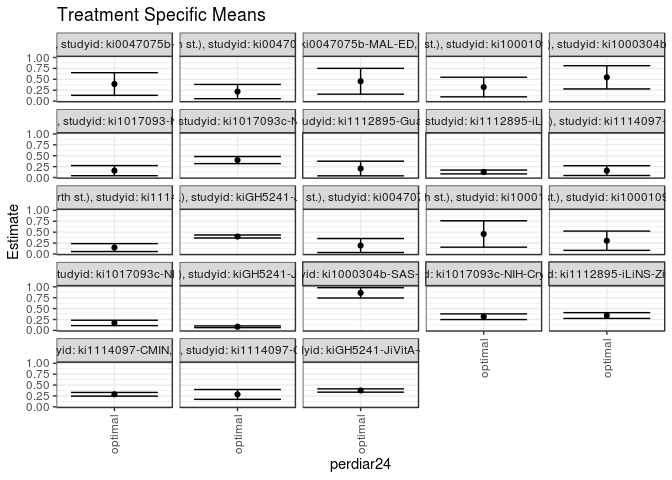

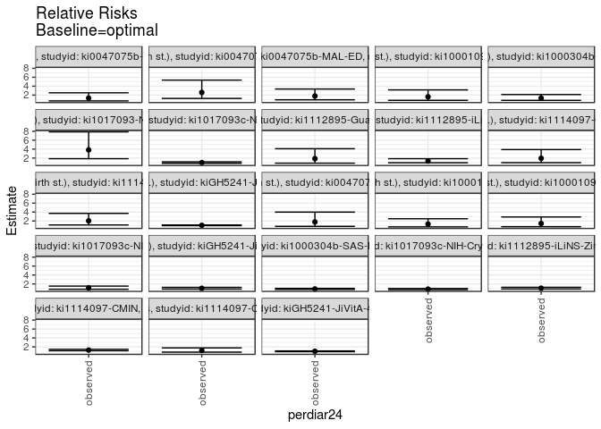

## Results Table

### Parameter: TSM

| agecat | studyid | country | intervention_level | baseline_level | estimate | ci_lower | ci_upper |
| --- | --- | --- | --- | --- | --- | --- | --- |
| 0-24 months (no birth st.) | ki0047075b-MAL-ED | BANGLADESH | optimal | NA | 0.3919981 | 0.1325438 | 0.6514525 |
| 0-24 months (no birth st.) | ki0047075b-MAL-ED | PERU | optimal | NA | 0.2188143 | 0.0554654 | 0.3821632 |
| 0-24 months (no birth st.) | ki0047075b-MAL-ED | TANZANIA, UNITED REPUBLIC OF | optimal | NA | 0.4551158 | 0.1594872 | 0.7507445 |
| 0-24 months (no birth st.) | ki1000109-ResPak | PAKISTAN | optimal | NA | 0.3228038 | 0.0977518 | 0.5478558 |
| 0-24 months (no birth st.) | ki1000304b-SAS-FoodSuppl | INDIA | optimal | NA | 0.5454447 | 0.2791143 | 0.8117752 |
| 0-24 months (no birth st.) | ki1017093-NIH-Birth | BANGLADESH | optimal | NA | 0.1580297 | 0.0421406 | 0.2739188 |
| 0-24 months (no birth st.) | ki1017093c-NIH-Crypto | BANGLADESH | optimal | NA | 0.4001522 | 0.3185788 | 0.4817257 |
| 0-24 months (no birth st.) | ki1112895-Guatemala BSC | GUATEMALA | optimal | NA | 0.2068210 | 0.0386851 | 0.3749569 |
| 0-24 months (no birth st.) | ki1112895-iLiNS-Zinc | BURKINA FASO | optimal | NA | 0.1275339 | 0.0835270 | 0.1715409 |
| 0-24 months (no birth st.) | ki1114097-CMIN | GUINEA-BISSAU | optimal | NA | 0.1591322 | 0.0470530 | 0.2712115 |
| 0-24 months (no birth st.) | ki1114097-CMIN | PERU | optimal | NA | 0.1466524 | 0.0561765 | 0.2371282 |
| 0-24 months (no birth st.) | kiGH5241-JiVitA-4 | BANGLADESH | optimal | NA | 0.4008433 | 0.3664362 | 0.4352505 |
| 0-6 months (no birth st.) | ki0047075b-MAL-ED | PERU | optimal | NA | 0.1934253 | 0.0329309 | 0.3539198 |
| 0-6 months (no birth st.) | ki1000109-EE | PAKISTAN | optimal | NA | 0.4584374 | 0.1557642 | 0.7611105 |
| 0-6 months (no birth st.) | ki1000109-ResPak | PAKISTAN | optimal | NA | 0.3035690 | 0.0829282 | 0.5242098 |
| 0-6 months (no birth st.) | ki1017093c-NIH-Crypto | BANGLADESH | optimal | NA | 0.1715909 | 0.1096277 | 0.2335540 |
| 0-6 months (no birth st.) | kiGH5241-JiVitA-4 | BANGLADESH | optimal | NA | 0.0834897 | 0.0635000 | 0.1034794 |
| 6-24 months | ki1000304b-SAS-FoodSuppl | INDIA | optimal | NA | 0.8616189 | 0.7428704 | 0.9803675 |
| 6-24 months | ki1017093c-NIH-Crypto | BANGLADESH | optimal | NA | 0.3133377 | 0.2484099 | 0.3782655 |
| 6-24 months | ki1112895-iLiNS-Zinc | BURKINA FASO | optimal | NA | 0.3415137 | 0.2750450 | 0.4079824 |
| 6-24 months | ki1114097-CMIN | GUINEA-BISSAU | optimal | NA | 0.2881413 | 0.2456107 | 0.3306718 |
| 6-24 months | ki1114097-CMIN | PERU | optimal | NA | 0.2850818 | 0.1723175 | 0.3978460 |
| 6-24 months | kiGH5241-JiVitA-4 | BANGLADESH | optimal | NA | 0.3750329 | 0.3367012 | 0.4133645 |

### Parameter: E(Y)

| agecat | studyid | country | intervention_level | baseline_level | estimate | ci_lower | ci_upper |
| --- | --- | --- | --- | --- | --- | --- | --- |
| 0-24 months (no birth st.) | ki0047075b-MAL-ED | BANGLADESH | observed | NA | 0.5207373 | 0.4541154 | 0.5873593 |
| 0-24 months (no birth st.) | ki0047075b-MAL-ED | PERU | observed | NA | 0.5676692 | 0.5080232 | 0.6273151 |
| 0-24 months (no birth st.) | ki0047075b-MAL-ED | TANZANIA, UNITED REPUBLIC OF | observed | NA | 0.8127854 | 0.7610035 | 0.8645672 |
| 0-24 months (no birth st.) | ki1000109-ResPak | PAKISTAN | observed | NA | 0.5223881 | 0.4531624 | 0.5916138 |
| 0-24 months (no birth st.) | ki1000304b-SAS-FoodSuppl | INDIA | observed | NA | 0.7198444 | 0.6648337 | 0.7748550 |
| 0-24 months (no birth st.) | ki1017093-NIH-Birth | BANGLADESH | observed | NA | 0.6041667 | 0.5624147 | 0.6459187 |
| 0-24 months (no birth st.) | ki1017093c-NIH-Crypto | BANGLADESH | observed | NA | 0.3935681 | 0.3560687 | 0.4310676 |
| 0-24 months (no birth st.) | ki1112895-Guatemala BSC | GUATEMALA | observed | NA | 0.3855932 | 0.3233622 | 0.4478242 |
| 0-24 months (no birth st.) | ki1112895-iLiNS-Zinc | BURKINA FASO | observed | NA | 0.1696617 | 0.1377362 | 0.2015872 |
| 0-24 months (no birth st.) | ki1114097-CMIN | GUINEA-BISSAU | observed | NA | 0.3085714 | 0.2826947 | 0.3344481 |
| 0-24 months (no birth st.) | ki1114097-CMIN | PERU | observed | NA | 0.2976339 | 0.2659904 | 0.3292773 |
| 0-24 months (no birth st.) | kiGH5241-JiVitA-4 | BANGLADESH | observed | NA | 0.4135358 | 0.3953404 | 0.4317312 |
| 0-6 months (no birth st.) | ki0047075b-MAL-ED | PERU | observed | NA | 0.3458647 | 0.2885967 | 0.4031327 |
| 0-6 months (no birth st.) | ki1000109-EE | PAKISTAN | observed | NA | 0.6024096 | 0.5415000 | 0.6633193 |
| 0-6 months (no birth st.) | ki1000109-ResPak | PAKISTAN | observed | NA | 0.4378109 | 0.3690538 | 0.5065681 |
| 0-6 months (no birth st.) | ki1017093c-NIH-Crypto | BANGLADESH | observed | NA | 0.1898928 | 0.1597870 | 0.2199986 |
| 0-6 months (no birth st.) | kiGH5241-JiVitA-4 | BANGLADESH | observed | NA | 0.0855425 | 0.0741829 | 0.0969021 |
| 6-24 months | ki1000304b-SAS-FoodSuppl | INDIA | observed | NA | 0.7572016 | 0.7031798 | 0.8112234 |
| 6-24 months | ki1017093c-NIH-Crypto | BANGLADESH | observed | NA | 0.2628458 | 0.2244546 | 0.3012371 |
| 6-24 months | ki1112895-iLiNS-Zinc | BURKINA FASO | observed | NA | 0.3592985 | 0.2940547 | 0.4245424 |
| 6-24 months | ki1114097-CMIN | GUINEA-BISSAU | observed | NA | 0.3706505 | 0.3446055 | 0.3966956 |
| 6-24 months | ki1114097-CMIN | PERU | observed | NA | 0.3450439 | 0.3120195 | 0.3780683 |
| 6-24 months | kiGH5241-JiVitA-4 | BANGLADESH | observed | NA | 0.3779118 | 0.3593176 | 0.3965059 |

### Parameter: RR

| agecat | studyid | country | intervention_level | baseline_level | estimate | ci_lower | ci_upper |
| --- | --- | --- | --- | --- | --- | --- | --- |
| 0-24 months (no birth st.) | ki0047075b-MAL-ED | BANGLADESH | observed | optimal | 1.3284178 | 0.7002888 | 2.5199518 |
| 0-24 months (no birth st.) | ki0047075b-MAL-ED | PERU | observed | optimal | 2.5942964 | 1.2559285 | 5.3588830 |
| 0-24 months (no birth st.) | ki0047075b-MAL-ED | TANZANIA, UNITED REPUBLIC OF | observed | optimal | 1.7858868 | 0.9485182 | 3.3624992 |
| 0-24 months (no birth st.) | ki1000109-ResPak | PAKISTAN | observed | optimal | 1.6182835 | 0.8269480 | 3.1668754 |
| 0-24 months (no birth st.) | ki1000304b-SAS-FoodSuppl | INDIA | observed | optimal | 1.3197384 | 0.8191185 | 2.1263216 |
| 0-24 months (no birth st.) | ki1017093-NIH-Birth | BANGLADESH | observed | optimal | 3.8231212 | 1.8578958 | 7.8671018 |
| 0-24 months (no birth st.) | ki1017093c-NIH-Crypto | BANGLADESH | observed | optimal | 0.9835460 | 0.8311316 | 1.1639105 |
| 0-24 months (no birth st.) | ki1112895-Guatemala BSC | GUATEMALA | observed | optimal | 1.8643818 | 0.8499527 | 4.0895447 |
| 0-24 months (no birth st.) | ki1112895-iLiNS-Zinc | BURKINA FASO | observed | optimal | 1.3303264 | 0.9537586 | 1.8555727 |
| 0-24 months (no birth st.) | ki1114097-CMIN | GUINEA-BISSAU | observed | optimal | 1.9390881 | 0.9661141 | 3.8919447 |
| 0-24 months (no birth st.) | ki1114097-CMIN | PERU | observed | optimal | 2.0295197 | 1.1102012 | 3.7100938 |
| 0-24 months (no birth st.) | kiGH5241-JiVitA-4 | BANGLADESH | observed | optimal | 1.0316643 | 0.9590738 | 1.1097491 |
| 0-6 months (no birth st.) | ki0047075b-MAL-ED | PERU | observed | optimal | 1.7881042 | 0.8010773 | 3.9912709 |
| 0-6 months (no birth st.) | ki1000109-EE | PAKISTAN | observed | optimal | 1.3140500 | 0.6899055 | 2.5028464 |
| 0-6 months (no birth st.) | ki1000109-ResPak | PAKISTAN | observed | optimal | 1.4422123 | 0.7174253 | 2.8992235 |
| 0-6 months (no birth st.) | ki1017093c-NIH-Crypto | BANGLADESH | observed | optimal | 1.1066603 | 0.8083116 | 1.5151299 |
| 0-6 months (no birth st.) | kiGH5241-JiVitA-4 | BANGLADESH | observed | optimal | 1.0245875 | 0.8503018 | 1.2345964 |
| 6-24 months | ki1000304b-SAS-FoodSuppl | INDIA | observed | optimal | 0.8788127 | 0.7674256 | 1.0063669 |
| 6-24 months | ki1017093c-NIH-Crypto | BANGLADESH | observed | optimal | 0.8388581 | 0.7186029 | 0.9792374 |
| 6-24 months | ki1112895-iLiNS-Zinc | BURKINA FASO | observed | optimal | 1.0520764 | 0.8827292 | 1.2539120 |
| 6-24 months | ki1114097-CMIN | GUINEA-BISSAU | observed | optimal | 1.2863501 | 1.1359300 | 1.4566888 |
| 6-24 months | ki1114097-CMIN | PERU | observed | optimal | 1.2103331 | 0.8265846 | 1.7722401 |
| 6-24 months | kiGH5241-JiVitA-4 | BANGLADESH | observed | optimal | 1.0076763 | 0.9216195 | 1.1017687 |

### Parameter: PAR

| agecat | studyid | country | intervention_level | baseline_level | estimate | ci_lower | ci_upper |
| --- | --- | --- | --- | --- | --- | --- | --- |
| 0-24 months (no birth st.) | ki0047075b-MAL-ED | BANGLADESH | optimal | NA | 0.1287392 | -0.1215923 | 0.3790706 |
| 0-24 months (no birth st.) | ki0047075b-MAL-ED | PERU | optimal | NA | 0.3488549 | 0.1906927 | 0.5070170 |
| 0-24 months (no birth st.) | ki0047075b-MAL-ED | TANZANIA, UNITED REPUBLIC OF | optimal | NA | 0.3576695 | 0.0737544 | 0.6415847 |
| 0-24 months (no birth st.) | ki1000109-ResPak | PAKISTAN | optimal | NA | 0.1995843 | -0.0161131 | 0.4152816 |
| 0-24 months (no birth st.) | ki1000304b-SAS-FoodSuppl | INDIA | optimal | NA | 0.1743996 | -0.0851663 | 0.4339655 |
| 0-24 months (no birth st.) | ki1017093-NIH-Birth | BANGLADESH | optimal | NA | 0.4461370 | 0.3317246 | 0.5605493 |
| 0-24 months (no birth st.) | ki1017093c-NIH-Crypto | BANGLADESH | optimal | NA | -0.0065841 | -0.0740438 | 0.0608756 |
| 0-24 months (no birth st.) | ki1112895-Guatemala BSC | GUATEMALA | optimal | NA | 0.1787723 | 0.0157814 | 0.3417631 |
| 0-24 months (no birth st.) | ki1112895-iLiNS-Zinc | BURKINA FASO | optimal | NA | 0.0421278 | -0.0026987 | 0.0869543 |
| 0-24 months (no birth st.) | ki1114097-CMIN | GUINEA-BISSAU | optimal | NA | 0.1494392 | 0.0382567 | 0.2606217 |
| 0-24 months (no birth st.) | ki1114097-CMIN | PERU | optimal | NA | 0.1509815 | 0.0617343 | 0.2402287 |
| 0-24 months (no birth st.) | kiGH5241-JiVitA-4 | BANGLADESH | optimal | NA | 0.0126924 | -0.0165492 | 0.0419341 |
| 0-6 months (no birth st.) | ki0047075b-MAL-ED | PERU | optimal | NA | 0.1524393 | -0.0033722 | 0.3082509 |
| 0-6 months (no birth st.) | ki1000109-EE | PAKISTAN | optimal | NA | 0.1439723 | -0.1505860 | 0.4385306 |
| 0-6 months (no birth st.) | ki1000109-ResPak | PAKISTAN | optimal | NA | 0.1342419 | -0.0772362 | 0.3457201 |
| 0-6 months (no birth st.) | ki1017093c-NIH-Crypto | BANGLADESH | optimal | NA | 0.0183019 | -0.0354906 | 0.0720945 |
| 0-6 months (no birth st.) | kiGH5241-JiVitA-4 | BANGLADESH | optimal | NA | 0.0020528 | -0.0134894 | 0.0175950 |
| 6-24 months | ki1000304b-SAS-FoodSuppl | INDIA | optimal | NA | -0.1044173 | -0.2197012 | 0.0108666 |
| 6-24 months | ki1017093c-NIH-Crypto | BANGLADESH | optimal | NA | -0.0504918 | -0.0991544 | -0.0018292 |
| 6-24 months | ki1112895-iLiNS-Zinc | BURKINA FASO | optimal | NA | 0.0177848 | -0.0435348 | 0.0791044 |
| 6-24 months | ki1114097-CMIN | GUINEA-BISSAU | optimal | NA | 0.0825093 | 0.0466670 | 0.1183515 |
| 6-24 months | ki1114097-CMIN | PERU | optimal | NA | 0.0599621 | -0.0487576 | 0.1686819 |
| 6-24 months | kiGH5241-JiVitA-4 | BANGLADESH | optimal | NA | 0.0028789 | -0.0305996 | 0.0363574 |

### Parameter: PAF

| agecat | studyid | country | intervention_level | baseline_level | estimate | ci_lower | ci_upper |
| --- | --- | --- | --- | --- | --- | --- | --- |
| 0-24 months (no birth st.) | ki0047075b-MAL-ED | BANGLADESH | optimal | NA | 0.2472248 | -0.4279823 | 0.6031670 |
| 0-24 months (no birth st.) | ki0047075b-MAL-ED | PERU | optimal | NA | 0.6145390 | 0.2037763 | 0.8133939 |
| 0-24 months (no birth st.) | ki0047075b-MAL-ED | TANZANIA, UNITED REPUBLIC OF | optimal | NA | 0.4400541 | -0.0542760 | 0.7026022 |
| 0-24 months (no birth st.) | ki1000109-ResPak | PAKISTAN | optimal | NA | 0.3820613 | -0.2092658 | 0.6842313 |
| 0-24 months (no birth st.) | ki1000304b-SAS-FoodSuppl | INDIA | optimal | NA | 0.2422741 | -0.2208246 | 0.5297043 |
| 0-24 months (no birth st.) | ki1017093-NIH-Birth | BANGLADESH | optimal | NA | 0.7384336 | 0.4617567 | 0.8728884 |
| 0-24 months (no birth st.) | ki1017093c-NIH-Crypto | BANGLADESH | optimal | NA | -0.0167292 | -0.2031789 | 0.1408274 |
| 0-24 months (no birth st.) | ki1112895-Guatemala BSC | GUATEMALA | optimal | NA | 0.4636292 | -0.1765361 | 0.7554740 |
| 0-24 months (no birth st.) | ki1112895-iLiNS-Zinc | BURKINA FASO | optimal | NA | 0.2483048 | -0.0484834 | 0.4610828 |
| 0-24 months (no birth st.) | ki1114097-CMIN | GUINEA-BISSAU | optimal | NA | 0.4842937 | -0.0350745 | 0.7430590 |
| 0-24 months (no birth st.) | ki1114097-CMIN | PERU | optimal | NA | 0.5072726 | 0.0992623 | 0.7304650 |
| 0-24 months (no birth st.) | kiGH5241-JiVitA-4 | BANGLADESH | optimal | NA | 0.0306925 | -0.0426726 | 0.0988954 |
| 0-6 months (no birth st.) | ki0047075b-MAL-ED | PERU | optimal | NA | 0.4407485 | -0.2483189 | 0.7494532 |
| 0-6 months (no birth st.) | ki1000109-EE | PAKISTAN | optimal | NA | 0.2389940 | -0.4494739 | 0.6004549 |
| 0-6 months (no birth st.) | ki1000109-ResPak | PAKISTAN | optimal | NA | 0.3066208 | -0.3938734 | 0.6550801 |
| 0-6 months (no birth st.) | ki1017093c-NIH-Crypto | BANGLADESH | optimal | NA | 0.0963803 | -0.2371467 | 0.3399906 |
| 0-6 months (no birth st.) | kiGH5241-JiVitA-4 | BANGLADESH | optimal | NA | 0.0239974 | -0.1760530 | 0.1900187 |
| 6-24 months | ki1000304b-SAS-FoodSuppl | INDIA | optimal | NA | -0.1378989 | -0.3030579 | 0.0063266 |
| 6-24 months | ki1017093c-NIH-Crypto | BANGLADESH | optimal | NA | -0.1920968 | -0.3915891 | -0.0212028 |
| 6-24 months | ki1112895-iLiNS-Zinc | BURKINA FASO | optimal | NA | 0.0494987 | -0.1328502 | 0.2024959 |
| 6-24 months | ki1114097-CMIN | GUINEA-BISSAU | optimal | NA | 0.2226066 | 0.1196640 | 0.3135116 |
| 6-24 months | ki1114097-CMIN | PERU | optimal | NA | 0.1737812 | -0.2097976 | 0.4357424 |
| 6-24 months | kiGH5241-JiVitA-4 | BANGLADESH | optimal | NA | 0.0076178 | -0.0850465 | 0.0923685 |